# Singapore Fertility, Female LFPR and Recessions

An integrated age-group view, 1980-2025

Author

Team 11

## Purpose

This visualisation combines five dimensions in one aligned figure:

- **Year** on the horizontal axis
- **Age-specific fertility rate (ASFR)** through stacked bar height
- **Female age group** through bar fill colour
- **Female labour-force participation rate (LFPR)** through matching dashed lines
- **Economic recessions** through vertical grey bands

The stacked bars show how each age group contributes to fertility, while matching dashed lines show female LFPR for the same age groups.

## 1. Setup

```r
library(tidyverse)
library(scales)
```

## 2. Paths and helper functions

```r
data_dir <- file.path("proposal_files", "datasets")

fertility_file <- file.path(data_dir, "BirthsAndFertilityRatesAnnual.csv")
lfpr_file      <- file.path(data_dir, "M182201.csv")

read_singstat_wide <- function(path) {
  lines <- readLines(path, warn = FALSE)

  header_index <- which(
    stringr::str_detect(lines, "^Data\\s*Series\\s*,")
  )[1]

  if (is.na(header_index)) {
    stop("No 'Data Series' header found in: ", path)
  }

  raw <- readr::read_csv(
    path,
    skip = header_index - 1,
    na = c("", "na", "NA", "N.A.", "-"),
    show_col_types = FALSE
  )

  raw <- dplyr::rename_with(raw, trimws)
  names(raw)[1] <- "data_series"

  raw |>
    mutate(data_series = stringr::str_squish(data_series)) |>
    filter(!is.na(data_series), data_series != "")
}

to_long_years <- function(data) {
  year_cols <- names(data)[
    stringr::str_detect(names(data), "^\\d{4}$")
  ]

  data |>
    pivot_longer(
      cols = all_of(year_cols),
      names_to = "year",
      values_to = "value"
    ) |>
    mutate(
      year = as.integer(year),
      value = readr::parse_number(as.character(value))
    ) |>
    filter(!is.na(year))
}

standardise_age_group <- function(x) {
  x |>
    stringr::str_squish() |>
    stringr::str_replace_all("\\s*-\\s*", "-")
}

age_groups <- c(
  "15-19 Years",
  "20-24 Years",
  "25-29 Years",
  "30-34 Years",
  "35-39 Years",
  "40-44 Years",
  "45-49 Years"
)
```

## 3. Build the cleaned tables

```r
# --- Fertility source table ---
fertility_raw <- read_singstat_wide(fertility_file)

# ASFR by mother's age group
asfr_by_age <- fertility_raw |>
  mutate(age_group = standardise_age_group(data_series)) |>
  filter(age_group %in% age_groups) |>
  to_long_years() |>
  transmute(
    year,
    age_group = factor(age_group, levels = age_groups),
    asfr = value
  ) |>
  filter(year >= 1980, !is.na(asfr)) |>
  arrange(age_group, year)

# --- Female LFPR by age group (SingStat M182201) ---
lfpr_female <- read_singstat_wide(lfpr_file) |>
  mutate(
    section = case_when(
      data_series == "Female Resident Participation Rate" ~ "Female",
      data_series %in% c(
        "Total Resident Participation Rate",
        "Male Resident Participation Rate"
      ) ~ "Other",
      TRUE ~ NA_character_
    )
  ) |>
  tidyr::fill(section, .direction = "down") |>
  filter(
    section == "Female",
    data_series != "Female Resident Participation Rate"
  ) |>
  mutate(age_group = standardise_age_group(data_series)) |>
  filter(age_group %in% age_groups) |>
  to_long_years() |>
  transmute(
    year,
    age_group = factor(age_group, levels = age_groups),
    female_lfpr_pct = value
  ) |>
  filter(year >= 1990, !is.na(female_lfpr_pct)) |>
  arrange(age_group, year)

# Combine age-specific fertility and female LFPR
age_group_data <- asfr_by_age |>
  inner_join(
    lfpr_female,
    by = c("year", "age_group")
  ) |>
  arrange(age_group, year)

# Recession periods used in the visualisation
recession_events <- tibble(
  recession = c(
    "1985 Singapore recession",
    "Asian Financial Crisis",
    "Global Financial Crisis",
    "COVID-19 recession"
  ),
  year = c(1985, 1998, 2009, 2020)
) |>
  mutate(
    xmin = year - 0.55,
    xmax = year + 0.55
  )

# Major pro-natalist policy milestones within the displayed period
birth_policy_events <- tibble(
  year = c(1984, 1987, 2001, 2004, 2008, 2013),
  policy = c(
    "Graduate Mothers Scheme",
    "Have Three or More policy",
    "Baby Bonus",
    "Marriage & Parenthood (M&P) Package",
    "Enhanced M&P Package",
    "Enhanced M&P Package"
  ),
  label_level = c(1, 2, 1, 2, 1, 2)
)
```

## 4. Data checks

```r
stopifnot(nrow(age_group_data) > 0)

age_group_data |>
  summarise(
    first_year = min(year),
    last_year = max(year),
    age_groups = n_distinct(age_group),
    observations = n()
  )
```

```
# A tibble: 1 × 4
  first_year last_year age_groups observations
       <int>     <int>      <int>        <int>
1       1990      2025          7          252
```

## 5. Integrated visualisation

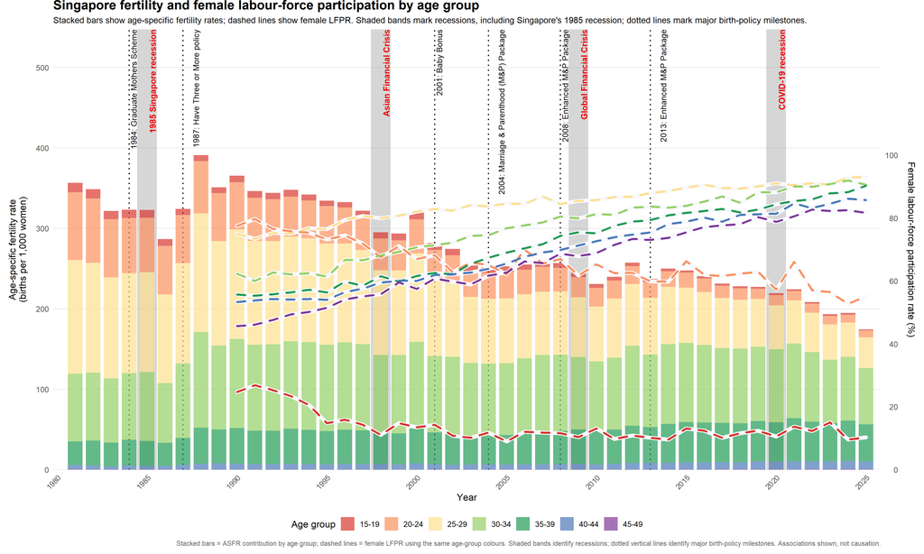

```r
common_x_scale <- scale_x_continuous(
  limits = c(1980, 2025.6),
  breaks = seq(1980, 2025, 5),
  expand = expansion(mult = c(0.005, 0.005))
)

# Main panel: stacked ASFR bars with LFPR lines

age_group_colours <- c(
  "15-19 Years" = "#D73027",
  "20-24 Years" = "#FC8D59",
  "25-29 Years" = "#FEE08B",
  "30-34 Years" = "#91CF60",
  "35-39 Years" = "#1A9850",
  "40-44 Years" = "#4575B4",
  "45-49 Years" = "#7B3294"
)

# Scale LFPR percentages onto the ASFR axis.
# The secondary axis reverses this exact transformation.
asfr_total_by_year <- asfr_by_age |>
  group_by(year) |>
  summarise(total_asfr = sum(asfr, na.rm = TRUE), .groups = "drop")

asfr_max <- max(asfr_total_by_year$total_asfr, na.rm = TRUE)
lfpr_scale <- asfr_max / 100

lfpr_line <- lfpr_female |>
  mutate(age_group = factor(age_group, levels = age_groups)) |>
  filter(
    year >= min(asfr_by_age$year),
    year <= max(asfr_by_age$year)
  )

p_age <- ggplot() +
  geom_rect(
    data = recession_events,
    aes(xmin = xmin, xmax = xmax, ymin = -Inf, ymax = Inf),
    inherit.aes = FALSE,
    fill = "gray60",
    alpha = 0.4
  ) +
  # Recession names are placed inside the shaded bands.
  geom_text(
    data = recession_events,
    aes(
      x = year,
      y = Inf,
      label = recession
    ),
    inherit.aes = FALSE,
    angle = 90,
    vjust = 1.35,
    hjust = 1,
    size = 3.5,
    fontface = "bold",
    colour = "red2"
  ) +
  # Dotted lines mark major birth-policy introductions or enhancements.
  geom_vline(
    data = birth_policy_events,
    aes(xintercept = year),
    inherit.aes = FALSE,
    linetype = "dotted",
    linewidth = 0.75,
    colour = "black",
    alpha = 1
  ) +
  geom_text(
    data = birth_policy_events,
    aes(
      x = year,
      y = Inf,
      label = paste0(year, ": ", policy),
      vjust = if_else(label_level == 1, 1.25, 2.65)
    ),
    inherit.aes = FALSE,
    angle = 90,
    hjust = 1,
    size = 3.3,
    colour = "black"
  ) +
  geom_col(
    data = asfr_by_age,
    aes(
      x = year,
      y = asfr,
      fill = age_group
    ),
    width = 0.82,
    alpha = 0.68
  ) +
  # White underlay keeps LFPR lines visible over similarly coloured bars.
  geom_line(
    data = lfpr_line,
    aes(
      x = year,
      y = female_lfpr_pct * lfpr_scale,
      group = age_group
    ),
    colour = "ghostwhite",
    linewidth = 2.2,
    alpha = 1,
    lineend = "round"
  ) +
  geom_line(
    data = lfpr_line,
    aes(
      x = year,
      y = female_lfpr_pct * lfpr_scale,
      colour = age_group,
      group = age_group
    ),
    linewidth = 1.2,
    linetype = "dashed",
    alpha = 0.98,
    lineend = "round"
  ) +
  common_x_scale +
  scale_y_continuous(
    name = "Age-specific fertility rate\n(births per 1,000 women)",
    sec.axis = sec_axis(
      ~ . / lfpr_scale,
      name = "Female labour-force participation rate (%)",
      breaks = seq(0, 100, 20)
    ),
    expand = expansion(mult = c(0, 0.40))
  ) +
  scale_fill_manual(
    values = age_group_colours,
    name = "Age group",
    labels = function(x) str_remove(x, " Years")
  ) +
  scale_colour_manual(
    values = age_group_colours,
    name = "Age group",
    labels = function(x) str_remove(x, " Years")
  ) +
  labs(
    x = "Year",
    caption = paste0(
      "Stacked bars = ASFR contribution by age group; dashed lines = female LFPR ",
      "using the same age-group colours. Shaded bands identify recessions; ",
      "dotted vertical lines identify major birth-policy milestones. ",
      "Associations shown, not causation."
    )
  ) +
  guides(
    fill = guide_legend(
      title = "Age group",
      order = 1,
      nrow = 1
    ),
    colour = "none"
  ) +
  theme_minimal(base_size = 11) +
  theme(
    panel.grid.minor = element_blank(),
    panel.grid.major.x = element_blank(),
    axis.text.x = element_text(angle = 45, hjust = 1),
    axis.title.y.left = element_text(margin = margin(r = 10)),
    axis.title.y.right = element_text(margin = margin(l = 10)),
    plot.caption = element_text(size = 8, colour = "grey40"),
    legend.position = "bottom",
    legend.box = "horizontal",
    plot.margin = margin(0, 10, 8, 10)
  )

p_age +
  labs(
    title = "Singapore fertility and female labour-force participation by age group",
    subtitle = paste0(
      "Stacked bars show age-specific fertility rates; dashed lines show female LFPR. ",
      "Shaded bands mark recessions, including Singapore's 1985 recession; dotted lines mark major birth-policy milestones."
    )
  ) +
  theme(
    plot.title = element_text(face = "bold", size = 15),
    plot.subtitle = element_text(size = 10)
  )
```

## 6. Interpretation guide

- Compare the stacked bar segments to see which age groups contributed most to changes in fertility.
- Each bar segment represents the ASFR contribution of one age group.
- The dashed line for each matching colour represents female LFPR for that age group on the right-hand percentage axis.
- Shaded recession bands allow the timing of fertility and labour-market changes to be compared with major economic downturns.
- Dotted vertical lines mark major pro-natalist policy introductions or enhancements during the displayed period.
- The chart shows temporal association only. It does not prove that LFPR, recessions, or policy changes caused changes in fertility.